# Chi-square tests and ANOVA

Katie Lankowicz

2023-07-26

```r
knitr::opts_chunk$set(echo = TRUE)

# Delete old data
rm(list=ls())

# Load packages, install nycflights13, rstatix, corrplot if you need to.
library(tidyverse)
library (nycflights13)
library(corrplot)
library(rstatix)
library(ggpubr)
```

Today we’ll be working on a dataframe of all flights that departed from New York City-area airports (JFK, LaGuardia, and Newark NJ) in 2013. The dataframe is contained in an R package called `nycflights`, so we don’t need to set any working directories or load any external data. Just install the package (if you don’t have it, and I don’t think you do) and then call the pre-existing dataframe called `flights`. Let’s see what it contains.

```r
# Because flights is a pre-prepared dataset in a package, we can use the ? function
# to see information regarding its contents.
?flights

# Check out the contents
summary(flights)
```

```
      year          month             day           dep_time    sched_dep_time
 Min.   :2013   Min.   : 1.000   Min.   : 1.00   Min.   :   1   Min.   : 106
 1st Qu.:2013   1st Qu.: 4.000   1st Qu.: 8.00   1st Qu.: 907   1st Qu.: 906
 Median :2013   Median : 7.000   Median :16.00   Median :1401   Median :1359
 Mean   :2013   Mean   : 6.549   Mean   :15.71   Mean   :1349   Mean   :1344
 3rd Qu.:2013   3rd Qu.:10.000   3rd Qu.:23.00   3rd Qu.:1744   3rd Qu.:1729
 Max.   :2013   Max.   :12.000   Max.   :31.00   Max.   :2400   Max.   :2359
                                                 NA's   :8255
   dep_delay          arr_time    sched_arr_time   arr_delay          carrier
 Min.   : -43.00   Min.   :   1   Min.   :   1   Min.   : -86.000   Length:336776
 1st Qu.:  -5.00   1st Qu.:1104   1st Qu.:1124   1st Qu.: -17.000   Class :character
 Median :  -2.00   Median :1535   Median :1556   Median :  -5.000   Mode  :character
 Mean   :  12.64   Mean   :1502   Mean   :1536   Mean   :   6.895
 3rd Qu.:  11.00   3rd Qu.:1940   3rd Qu.:1945   3rd Qu.:  14.000
 Max.   :1301.00   Max.   :2400   Max.   :2359   Max.   :1272.000
 NA's   :8255      NA's   :8713                  NA's   :9430
     flight       tailnum             origin              dest
 Min.   :   1   Length:336776      Length:336776      Length:336776
 1st Qu.: 553   Class :character   Class :character   Class :character
 Median :1496   Mode  :character   Mode  :character   Mode  :character
 Mean   :1972
 3rd Qu.:3465
 Max.   :8500

    air_time        distance         hour           minute
 Min.   : 20.0   Min.   :  17   Min.   : 1.00   Min.   : 0.00
 1st Qu.: 82.0   1st Qu.: 502   1st Qu.: 9.00   1st Qu.: 8.00
 Median :129.0   Median : 872   Median :13.00   Median :29.00
 Mean   :150.7   Mean   :1040   Mean   :13.18   Mean   :26.23
 3rd Qu.:192.0   3rd Qu.:1389   3rd Qu.:17.00   3rd Qu.:44.00
 Max.   :695.0   Max.   :4983   Max.   :23.00   Max.   :59.00
 NA's   :9430
   time_hour
 Min.   :2013-01-01 05:00:00.00
 1st Qu.:2013-04-04 13:00:00.00
 Median :2013-07-03 10:00:00.00
 Mean   :2013-07-03 05:22:54.64
 3rd Qu.:2013-10-01 07:00:00.00
 Max.   :2013-12-31 23:00:00.00
```

```r
str(flights)
```

```
tibble [336,776 × 19] (S3: tbl_df/tbl/data.frame)
 $ year          : int [1:336776] 2013 2013 2013 2013 2013 2013 2013 2013 2013 2013 ...
 $ month         : int [1:336776] 1 1 1 1 1 1 1 1 1 1 ...
 $ day           : int [1:336776] 1 1 1 1 1 1 1 1 1 1 ...
 $ dep_time      : int [1:336776] 517 533 542 544 554 554 555 557 557 558 ...
 $ sched_dep_time: int [1:336776] 515 529 540 545 600 558 600 600 600 600 ...
 $ dep_delay     : num [1:336776] 2 4 2 -1 -6 -4 -5 -3 -3 -2 ...
 $ arr_time      : int [1:336776] 830 850 923 1004 812 740 913 709 838 753 ...
 $ sched_arr_time: int [1:336776] 819 830 850 1022 837 728 854 723 846 745 ...
 $ arr_delay     : num [1:336776] 11 20 33 -18 -25 12 19 -14 -8 8 ...
 $ carrier       : chr [1:336776] "UA" "UA" "AA" "B6" ...
 $ flight        : int [1:336776] 1545 1714 1141 725 461 1696 507 5708 79 301 ...
 $ tailnum       : chr [1:336776] "N14228" "N24211" "N619AA" "N804JB" ...
 $ origin        : chr [1:336776] "EWR" "LGA" "JFK" "JFK" ...
 $ dest          : chr [1:336776] "IAH" "IAH" "MIA" "BQN" ...
 $ air_time      : num [1:336776] 227 227 160 183 116 150 158 53 140 138 ...
 $ distance      : num [1:336776] 1400 1416 1089 1576 762 ...
 $ hour          : num [1:336776] 5 5 5 5 6 5 6 6 6 6 ...
 $ minute        : num [1:336776] 15 29 40 45 0 58 0 0 0 0 ...
 $ time_hour     : POSIXct[1:336776], format: "2013-01-01 05:00:00" "2013-01-01 05:00:00" ...
```

## Data cleaning

Let’s do some data cleaning. We have some missing values to deal with. We also have some incorrect data types– R frequently reads what should be factor variables as characters. This means it does not recognize that your categorical variable has levels, and instead it’s only reading and saving the data as strings of letters. We can fix all this and remove variables that we will not use in this example.

```r
# Adapt flight dataset
flights2 <- flights %>%
  # Save only variables that we want to use
  select(month, day, dep_time, sched_dep_time, dep_delay,
         carrier, origin, dest, time_hour, tailnum) %>%
  # Remove cancelled flights
  na.omit() %>%
  # Change data type for carrier, origin, destination to factor
  mutate_if(is.character, as.factor)

# Determine which airports have fewer than 50 arrivals from NYC
uncommon_airports <- flights2 %>%
  # Group by destination
  group_by(dest) %>%
  # Summarise results: count number of arrivals to each destination
  summarise(count = n()) %>%
  # Filter out airports with fewer than 50 arrivals from NYC
  filter(count < 50) %>%
  # Remove count column
  mutate(count = NULL) %>%
  # Convert to a vector
  pull(dest) %>%
  # Remove levels that now have 0 samples
  droplevels()

# Determine which carriers have fewer than 50 departures from NYC
uncommon_carriers <- flights2 %>%
  # Group by carrier
  group_by(carrier) %>%
  # Summarize results: count number of times each carrier left NYC
  summarise(count = n()) %>%
  # Filter out carriers with fewer than 50 total departures from NYC
  filter(count < 50) %>%
  # Remove count column
  mutate(count = NULL) %>%
  # Convert to a vector
  pull(carrier) %>%
  # Remove levels that now have 0 samples
  droplevels()

# Build negate function
'%notin%' <- function(x,y)!('%in%'(x,y))
# I like this function and use it a lot. It's not included in Base R.
# This is the inverse of "must include," so you can think of it as "must not include"

# Remove uncommon airports from dataset
flights2 <- flights2 %>%
  filter(dest %notin% uncommon_airports)

# Remove uncommon carriers from dataset
flights2 <- flights2 %>%
  filter(carrier %notin% uncommon_carriers)

# Check results
table(flights2$dest)
```

```
  ABQ   ACK   ALB   ANC   ATL   AUS   AVL   BDL   BGR   BHM   BNA   BOS   BQN   BTV
  254   265   419     0 16898  2418   263   412   360   272  6104 15049   891  2513
  BUF   BUR   BWI   BZN   CAE   CAK   CHO   CHS   CLE   CLT   CMH   CRW   CVG   DAY
 4576   370  1696     0   107   843     0  2775  4387 13698  3338   137  3740  1402
  DCA   DEN   DFW   DSM   DTW   EGE   EYW   FLL   GRR   GSO   GSP   HDN   HNL   HOU
 9157  7201  8463   528  9058   208     0 11934   735  1500   794     0   705  2090
  IAD   IAH   ILM   IND   JAC   JAX   LAS   LAX   LEX   LGB   MCI   MCO   MDW   MEM
 5390  7103   108  1991     0  2634  5962 16076     0   664  1896 13982  4044  1694
  MHT   MIA   MKE   MSN   MSP   MSY   MTJ   MVY   MYR   OAK   OKC   OMA   ORD   ORF
  932 11633  2718   562  6954  3724     0   213    58   311   327   822 16641  1440
  PBI   PDX   PHL   PHX   PIT   PSE   PSP   PVD   PWM   RDU   RIC   ROC   RSW   SAN
 6495  1348  1549  4611  2759   361     0   358  2295  7796  2349  2362  3509  2724
  SAT   SAV   SBN   SDF   SEA   SFO   SJC   SJU   SLC   SMF   SNA   SRQ   STL   STT
  678   753     0  1117  3904 13230   328  5791  2458   282   819  1203  4168   518
  SYR   TPA   TUL   TVC   TYS   XNA
 1711  7407   299    96   579  1011
```

```r
table(flights2$carrier)
```

```
   9E    AA    AS    B6    DL    EV    F9    FL    HA    MQ    OO    UA    US    VX
17415 32093   712 54169 47742 51300   682  3187   342 25163     0 57888 19873  5113
   WN    YV
12083   545
```

```r
# Drop levels with 0 samples
flights2 <- droplevels(flights2)

# View results
summary(flights2)
```

```
     month             day           dep_time    sched_dep_time   dep_delay
 Min.   : 1.000   Min.   : 1.00   Min.   :   1   Min.   : 500   Min.   : -43.00
 1st Qu.: 4.000   1st Qu.: 8.00   1st Qu.: 907   1st Qu.: 905   1st Qu.:  -5.00
 Median : 7.000   Median :16.00   Median :1401   Median :1355   Median :  -2.00
 Mean   : 6.564   Mean   :15.74   Mean   :1349   Mean   :1341   Mean   :  12.64
 3rd Qu.:10.000   3rd Qu.:23.00   3rd Qu.:1744   3rd Qu.:1729   3rd Qu.:  11.00
 Max.   :12.000   Max.   :31.00   Max.   :2400   Max.   :2359   Max.   :1301.00

    carrier      origin            dest          time_hour
 UA     :57888   EWR:117495   ATL    : 16898   Min.   :2013-01-01 05:00:00.00
 B6     :54169   JFK:109396   ORD    : 16641   1st Qu.:2013-04-05 07:00:00.00
 EV     :51300   LGA:101416   LAX    : 16076   Median :2013-07-04 09:00:00.00
 DL     :47742                BOS    : 15049   Mean   :2013-07-03 17:27:20.69
 AA     :32093                MCO    : 13982   3rd Qu.:2013-10-01 16:00:00.00
 MQ     :25163                CLT    : 13698   Max.   :2013-12-31 23:00:00.00
 (Other):59952                (Other):235963
    tailnum
 N725MQ :   546
 N722MQ :   487
 N723MQ :   480
 N711MQ :   467
 N713MQ :   455
 N258JB :   422
 (Other):325450
```

Great. Let’s now make a new column where we convert the departure date to day of the week. Typically, we’d have to make sure that the column that contains the date information is understood by R to be a date. Luckily, our input this time has already been structure so R understands it is a date. I will write some code out anyway so you can see how you would tell R that your date is actually a date, but I will comment it out so it doesn’t run.

```r
# Check date structure
str(flights2$time_hour)
```

```
 POSIXct[1:328307], format: "2013-01-01 05:00:00" "2013-01-01 05:00:00" "2013-01-01 05:00:00" ...
```

```r
# Convert characters to date (don't need to run, it already is a date)
# flights2$time_hour <- as.POSIXct(flights2$time_hour,
#                                  format="%Y-%m-%d %H:%M:%S")

# Convert date-time to day of week
flights2$weekday <- weekdays(flights2$time_hour)

# Convert to factor - put days in order (otherwise they will be alphabetical)
flights2$weekday <- factor(flights2$weekday,
                           levels=c("Sunday", "Monday", "Tuesday",
                                    "Wednesday", "Thursday", "Friday",
                                    "Saturday"))

# View result
summary(flights2)
```

```
     month             day           dep_time    sched_dep_time   dep_delay
 Min.   : 1.000   Min.   : 1.00   Min.   :   1   Min.   : 500   Min.   : -43.00
 1st Qu.: 4.000   1st Qu.: 8.00   1st Qu.: 907   1st Qu.: 905   1st Qu.:  -5.00
 Median : 7.000   Median :16.00   Median :1401   Median :1355   Median :  -2.00
 Mean   : 6.564   Mean   :15.74   Mean   :1349   Mean   :1341   Mean   :  12.64
 3rd Qu.:10.000   3rd Qu.:23.00   3rd Qu.:1744   3rd Qu.:1729   3rd Qu.:  11.00
 Max.   :12.000   Max.   :31.00   Max.   :2400   Max.   :2359   Max.   :1301.00

    carrier      origin            dest          time_hour
 UA     :57888   EWR:117495   ATL    : 16898   Min.   :2013-01-01 05:00:00.00
 B6     :54169   JFK:109396   ORD    : 16641   1st Qu.:2013-04-05 07:00:00.00
 EV     :51300   LGA:101416   LAX    : 16076   Median :2013-07-04 09:00:00.00
 DL     :47742                BOS    : 15049   Mean   :2013-07-03 17:27:20.69
 AA     :32093                MCO    : 13982   3rd Qu.:2013-10-01 16:00:00.00
 MQ     :25163                CLT    : 13698   Max.   :2013-12-31 23:00:00.00
 (Other):59952                (Other):235963
    tailnum            weekday
 N725MQ :   546   Sunday   :45608
 N722MQ :   487   Monday   :49457
 N723MQ :   480   Tuesday  :49254
 N711MQ :   467   Wednesday:48845
 N713MQ :   455   Thursday :48644
 N258JB :   422   Friday   :48677
 (Other):325450   Saturday :37822
```

## Chi-square goodness of fit test

Let’s test if flights are equally as likely to leave NYC on all days of the week. This is a test where we only have one categorical variable– day of week. Day of week has 7 levels (Sunday through Saturday).

The test that we’ll use to address our question is a Chi-square goodness of fit test. This method tests if the observed distribution of results matches the expected distribution of results under the null hypothesis. In this case, the null hypothesis is that all days of the week have an equal proportion of flights. The alternative hypothesis would be that at least one day of the week does not have an equal proportion of flights. Under our null hypothesis, the expected distribution of flights would be (100% of flights / 7 days per week) 14% of flights taken on each day of the week.

There are some assumptions we must consider before going ahead with this test. Chi-square tests require independence of observations, meaning we can’t be using the same participant (flight, day of week, whatever) over time. We know that our data are independent. Chi-square tests also require observations to be mutually exclusive– we can’t have a case where a flight was taken on both Monday and Tuesday. Since the laws of time cannot possibly allow this, we’re fine on that front. Finally, Chi-square tests can only be used when we expect there to be 5 or more observations of each outcome. In this case, the flights dataset has more than 328,000 flights. If we expect each day of the week to contain around 14% of flights, we expect more than 45,000 flights for each day of the week. We therefore meet all assumptions and can proceed.

We’ll use a confidence level of 95%, so in order to reject our null hypothesis, the p-value will need to be less than 0.05.

```r
# Run chi-square test of proportions
chisq.test(x=flight.tab,            # Call data
           p=rep(flight.expect, 7)) # Call probability: 14.28% on each day of 7 days
```

```
    Chi-squared test for given probabilities

data:  flight.tab
X-squared = 2263.1, df = 6, p-value < 2.2e-16
```

Our p-value is way smaller than 0.05, indicating that at least one weekday has a significantly different proportion of flights than we would expect if all weekdays contained the same number of flights. Let’s make some calculations and a plot to determine which days of the week have a different proportion of flights than what we expect under the null hypothesis.

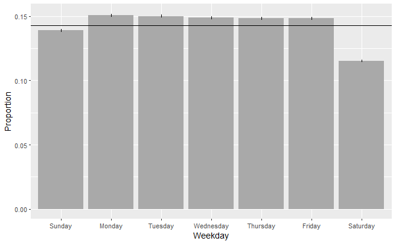

This is a barplot showing the proportion of flights taken each week day (bar height) and the 95% confidence interval of what we expect the true proportion of flights taken each day to be (little vertical line on each bar). We also have plotted a horizontal line showing the expected proportion of flights taken each day.

Notice that none of our confidence intervals (vertical lines) cross over our expected proportion (horizontal line). This means all of the days of the week have significantly different proportions of flights than what we would expect if the distribution was equal on each day. Sunday and Saturday have fewer flights than expected and Monday-Friday all have more flights than expected.

## Chi-square test of independence

Let’s test if there is an association between Carrier and Day of Week. The outcome will tell us if our carriers are equally as likely to depart from NYC airports all days of the week, or if any carrier is more likely to depart on specific days of the week. Both carrier and day of the week are categorical variables, and both have several levels. Day of week obviously has 7 levels, and carrier has 15 levels.

The test we’ll use to determine the answer is a Chi-square test of independence. NOTE THAT THIS IS A DIFFERENT CHI-SQUARE TEST THAN THE ONE WE JUST RAN. Our previous test was a goodness of fit test, in which we only use one categorical variable. This test requires two categorical variables. The rest of our assumptions are the same– we must have independent, mutually exclusive samples. We already know this to be true. We also must have an expected count of at least 5 samples per outcome. In this case, our smallest carrier (HA, Hawaiian airlines) has 342 total departures from NYC in this dataset. We would therefore expect 342 departures / 7 days per week = around 49 departures per weekday. We definitely meet the final assumption.

The null hypothesis of the Chi-square test of independence is that carrier and day of week are independent of each other. The alternative hypothesis is that there is an association between carrier and day of week. We will use a confidence level of 95%, which means to reject our null hypothesis, the p-value of the test outcome will need to be less than 0.05.

```r
# Make a contingency table to count number of departures on each day of the week
# by each carrier.
dep.table <- table(flights2$carrier, flights2$weekday)

# Run Chi-square test of independence
chisq.test(dep.table)
```

```
    Pearson's Chi-squared test

data:  dep.table
X-squared = 745.88, df = 84, p-value < 2.2e-16
```

The p-value is very small. This indicates that we have enough evidence to reject the null hypothesis and accept the alternative. We can say that some carriers are more likely to depart on certain days of the week. Let’s see if we can determine which carriers these are, and which days they’re more likely to depart.

To get some idea of what is going on, we will use a mosaic plot.

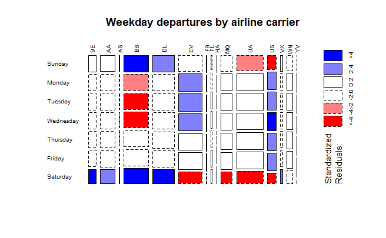

```r
# Create mosaic plot
mosaicplot(dep.table,             # Call data
           shade = TRUE,          # Set option to color by residual
           las=2,                 # Set axis labels for better plot visualization
           main = "Weekday departures by airline carrier") # Plot title
```

In this plot, days of the week are on the Y axis and airline carriers are on the X axis. Notice that the columns of this plot are different widths– this is so you can determine the relative frequency of each outcome. For example, the UA column is very wide and the YV column is very thin. This is because way more UA flights depart from NYC airports than YV flights. UA is the call sign for United (a huge company) and YV is the call sign for Mesa Airlines, a tiny regional company from Arizona.

Some boxes are colored red or blue. Red colors indicate a negative association (less likely than the null hypothesis would indicate) and blue colors indicate a positive association (more likely than the null hypothesis would indicate). The saturation (strength) of the color indicates the strength of that association. Boxes without a color do not have an association between that airline and that day of the week.

From the plot, we can see that most airlines have some sort of weekday pattern of flights. For example, United Airlines (UA) has fewer flights on Saturdays and Sundays than we would expect if the null hypothesis of no association was true. Endeavor Airlines (9E) has more flights on Saturday than would be expected if the null hypothesis of no association was true.

It’s kind of hard to determine what’s going on in those super-thin columns. Let’s adjust our visualization so that all columns are the same width, regardless of number of departures.

```r
# Save chi-square results
chisq <- chisq.test(dep.table)

# Pull residuals
round(chisq$residuals, 2)
```

```
     Sunday Monday Tuesday Wednesday Thursday Friday Saturday
  9E   1.72  -1.80   -0.76     -1.37    -0.93  -0.41     4.12
  AA   1.04  -0.80   -0.96     -1.37    -0.61  -0.45     3.63
  AS   0.11  -0.31   -0.08     -0.77    -0.73  -0.25     2.32
  B6   4.07  -3.01   -4.12     -5.18    -1.47  -1.51    12.96
  DL   2.02  -1.45   -1.28     -1.19    -1.27  -1.22     5.07
  EV  -0.42   2.25    2.56      3.13     0.17   0.42    -9.27
  F9   0.64   0.22    0.17      0.35     0.09   0.39    -2.09
  FL  -2.08   0.00    0.50      0.04    -0.01   0.16     1.51
  HA   0.65   0.07   -1.30      0.16    -1.50   0.18     2.01
  MQ  -0.47   0.88    1.35      1.44     0.70   0.77    -5.35
  UA  -2.32   1.72    0.84      1.45     1.64   0.80    -4.80
  US  -6.01   2.14    3.29      4.18     2.33   2.20    -9.50
  VX   0.06  -0.58   -0.26     -0.32    -0.24  -0.62     2.22
  WN  -1.28   0.44    0.41      0.27     0.13   0.27    -0.32
  YV  -0.31   1.20    0.80      0.66     1.14   1.36    -5.53
```

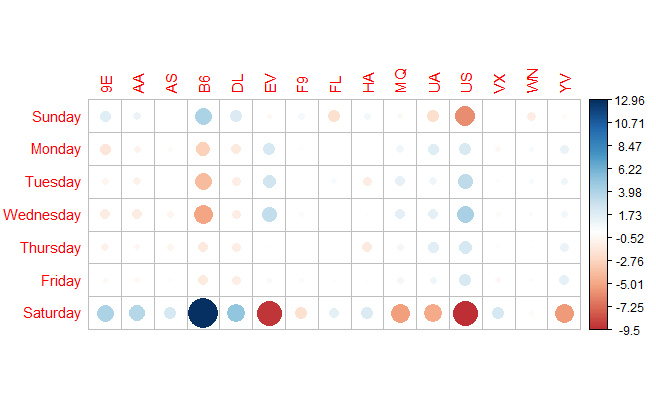

```r
# Plot Pearson correlation of residuals
corrplot(t(chisq$residuals), # Transpose so it's shaped the same as prev. plot
         is.cor = FALSE) # Tell R this isn't traditional correlation matrix
```

This plot is functionally the same as the previous one. It gives us all the same information, it just does so in a way that makes all the columns an equal size. Now we can more clearly see what is going on with small carriers like AS (Alaska Airlines), F9 (Frontier), and FL (AirTran Airways).

We can make a quantitative determination of which cell in our mosaic plot is contributing the most weight to our result. To do this, we will calculate and retain the chi-square value for each cell, then pull the residual values for each cell.

```r
# Calculate relative contribution of each cell to overall result
# (values are percents)
contrib <- 100*chisq$residuals^2/chisq$statistic
round(t(contrib), 2)
```

```
               9E    AA    AS    B6    DL    EV    F9    FL    HA    MQ    UA
  Sunday     0.40  0.15  0.00  2.22  0.55  0.02  0.06  0.58  0.06  0.03  0.72
  Monday     0.44  0.09  0.01  1.22  0.28  0.68  0.01  0.00  0.00  0.10  0.40
  Tuesday    0.08  0.12  0.00  2.28  0.22  0.88  0.00  0.03  0.23  0.24  0.09
  Wednesday  0.25  0.25  0.08  3.60  0.19  1.32  0.02  0.00  0.00  0.28  0.28
  Thursday   0.12  0.05  0.07  0.29  0.22  0.00  0.00  0.00  0.30  0.07  0.36
  Friday     0.02  0.03  0.01  0.31  0.20  0.02  0.02  0.00  0.00  0.08  0.09
  Saturday   2.28  1.77  0.72 22.51  3.45 11.53  0.59  0.30  0.54  3.83  3.09

               US    VX    WN    YV
  Sunday     4.84  0.00  0.22  0.01
  Monday     0.62  0.05  0.03  0.19
  Tuesday    1.45  0.01  0.02  0.09
  Wednesday  2.34  0.01  0.01  0.06
  Thursday   0.73  0.01  0.00  0.17
  Friday     0.65  0.05  0.01  0.25
  Saturday  12.09  0.66  0.01  4.09
```

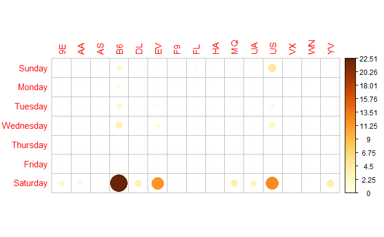

```r
# Visualize contribution
corrplot(t(contrib), is.cor = FALSE)
```

So we have some very strong associations that contribute a lot to the overall result. Carrier B6 (JetBlue) has a super strong association with Saturdays– the above plots indicate that they are far more likely to depart on Saturdays than we would expect if there was no association. Other strong results are Saturday departures for carriers EV (ExpressJet) and US (US Express). Note that according to the above plots, these carriers are far LESS likely to depart on Saturdays than one would expect if there was no association. This is the opposite from what we have seen with JetBlue. Make sure that you understand that the contribution plot only tells us how much each cell affects the overall outcome of the test (the p-value), and does not indicate the direction of the association (positive or negative).

## Analysis of Variance (ANOVA)

Chi-square tests of independence determine association between two categorical variables, each with multiple (2 or more) levels. What if we want to test the relationship between a categorical variable with many (3 or more) levels and a quantitative variable? For that, we would use Analysis of Variance (or ANOVA) tests. We’ll continue to use the flights dataset.

Let’s test if mean delay time varies by NYC airport (remember we have data for JFK, LaGuardia, and Newark NJ). We’ll use airport as the explanatory variable and departure delay time as the response variable. Origin airport is a categorical variable. Departure delay time is a numeric variable. It’s reported as minutes away from the scheduled departure. Negative values are flights that left earlier than they were supposed to, while positive values are flights that left later than they were supposed to.

The idea behind the ANOVA test is very simple: if the average variation between groups (variation in delay between airports) is large enough compared to the average variation within groups (variation in delay within airports), then you could conclude that at least one group mean is not equal to the others. Thus, it’s possible to evaluate whether the differences between the group means are significant by comparing the two variance estimates. This is why the method is called analysis of variance even though the main goal is to compare the group means.

We need to think about the assumptions of ANOVA. First of all, it requires a categorical variable and a numeric variable. We’ve already checked that. ANOVA also requires independence of observations. We already have addressed this too, we know that we aren’t using repeated measures of the same flight. Finally, we need to check for outliers, normality, and equal variance between groups. We will check for outliers before performing the test and remove any extreme outliers. We will save checking normality and equality of variance for when we have residuals from our model. By waiting until we have residuals, we can look at normality and variance for all groups together. This is easier than checking normality and variance for each day separately, which we would have to do if we weren’t using residuals.

```r
nrow(outlier.check[outlier.check$is.extreme==TRUE,])
```

```
[1] 27422
```

[figure not shown]

```r
# View results
summary(res_aov)
```

```
                Df   Sum Sq Mean Sq F value Pr(>F)
origin           2  1432194  716097    3597 <2e-16 ***
Residuals   300882 59893214     199
---
Signif. codes:  0 ‘***’ 0.001 ‘**’ 0.01 ‘*’ 0.05 ‘.’ 0.1 ‘ ’ 1
```

We now have our outcome. The p-value column shows us that the mean delay time is significantly different between the levels of origin airport (Newark NJ, JFK, and LaGuardia). To quantitatively determine which airports are significantly different to each other, we need to run a “post-hoc” (after the fact) test.

```r
# Run Tukey's post-hoc test to determine which airports are different
TukeyHSD(res_aov, "origin", conf.level = 0.95)
```

```
  Tukey multiple comparisons of means
    95% family-wise confidence level

Fit: aov(formula = dep_delay ~ origin, data = flights3)

$origin
             diff       lwr       upr p adj
JFK-EWR -2.907593 -3.052424 -2.762762     0
LGA-EWR -5.334377 -5.482508 -5.186247     0
LGA-JFK -2.426785 -2.577765 -2.275804     0
```

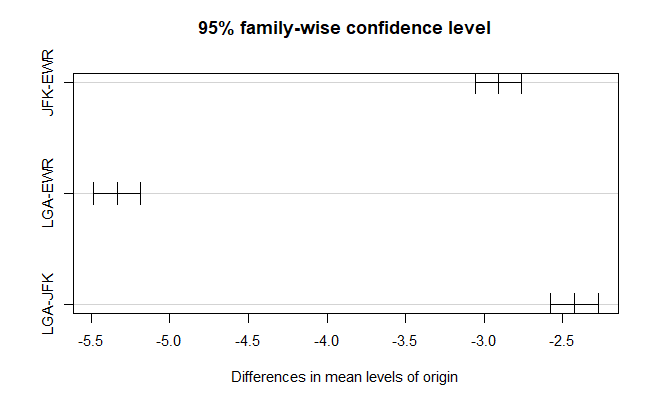

```r
# Plot pairwise comparisons
plot(TukeyHSD(res_aov))
```

Both the post-hoc test and the plot show us the same thing: it looks like all possible pairs of airport comparisons are significantly different. If the model residuals indicate we meet all the assumptions of ANOVA, we say that LaGuardia has a significantly shorter delay time than both JFK and Newark, that JFK has a signifcantly shorter delay time than Newark, and that Newark has a significantly longer delay time than both JFK and LaGuardia.

Let’s go back and address the assumptions of normality and equality of variance, starting with normality.

```r
# Quantitative tests of normality
# Usually you'd use a Shapiro-Wilk test, but we actually have too many samples.
# shapiro.test(res_aov$residuals)
# Instead, we'll use an Anderson-Darling test.
ad.test(res_aov$residuals)
```

```
    Anderson-Darling normality test

data:  res_aov$residuals
A = 24735, p-value < 2.2e-16
```

So, these data are not good candidates for parametric assessments like ANOVA! Instead, we can shift to non-parametric methods of assessing means. We’ll use the Kruskal-Wallis test, which does not have assumptions of normality or equal variance like ANOVA. It otherwise does functionally the same thing–tests if the means of two groups are equal.

## Kruskal-Wallis tests

The only assumptions needed for a Kruskal-Wallis test are that the samples are random and mutually independent. We already know that we are not using the same flight multiple times. We can proceed with the test.

```r
# Run K-W test
kruskal.test(flights3$dep_delay,
             flights3$origin)
```

[output not shown]

```r
agricolae::kruskal(y=flights3$dep_delay,
                        trt=flights3$origin,
                        alpha=0.05,
                        p.adj='bonferroni',
                        group=TRUE,
                        console=TRUE)
```

[output not shown]

Because Kruskal-Wallis tests do not need to meet the assumptions of normality and equality of variance like ANOVA, we can now certify these results. LaGuardia has the shortest mean departure delay time, JFK’s delay time is significantly longer than LaGuardia but also significantly shorter than Newark NJ, and Newark NJ has significantly longer departure delay times than both JFK and LaGuardia.